# Exploration of Ford GoBike system data (by Rodion Boriskin)

## 1. Introduction

This data set includes information about individual rides made in a bike-sharing system covering the greater San Francisco Bay area.

Back to table of content

## 2. Preliminary Wrangling

```python
# import all packages and set plots to be embedded inline
import numpy as np
import pandas as pd
import matplotlib.pyplot as plt
import seaborn as sb
import math       # module to work with maths functions
import utm        # module to convert lat and long to meters

%matplotlib inline
```

```python
#read dataset
df = pd.read_csv('201902_fordgobike_tripdata.csv')
#create working copy
fgb_df = df.copy()
```

```python
#fgb_df = pd.read_csv('201902-fordgobike-tripdata.csv')
```

```python
#visulize dataset and content
fgb_df.head(5)
```

|  | duration_sec | start_time | end_time | start_station_id | start_station_name | start_station_latitude | start_station_longitude | end_station_id | end_station_name | end_station_latitude | end_station_longitude | bike_id | user_type | member_birth_year | member_gender | bike_share_for_all_trip |
| --- | --- | --- | --- | --- | --- | --- | --- | --- | --- | --- | --- | --- | --- | --- | --- | --- |
| 0 | 52185 | 2019-02-28 17:32:10.1450 | 2019-03-01 08:01:55.9750 | 21.0 | Montgomery St BART Station (Market St at 2nd St) | 37.789625 | -122.400811 | 13.0 | Commercial St at Montgomery St | 37.794231 | -122.402923 | 4902 | Customer | 1984.0 | Male | No |
| 1 | 42521 | 2019-02-28 18:53:21.7890 | 2019-03-01 06:42:03.0560 | 23.0 | The Embarcadero at Steuart St | 37.791464 | -122.391034 | 81.0 | Berry St at 4th St | 37.775880 | -122.393170 | 2535 | Customer | NaN | NaN | No |
| 2 | 61854 | 2019-02-28 12:13:13.2180 | 2019-03-01 05:24:08.1460 | 86.0 | Market St at Dolores St | 37.769305 | -122.426826 | 3.0 | Powell St BART Station (Market St at 4th St) | 37.786375 | -122.404904 | 5905 | Customer | 1972.0 | Male | No |
| 3 | 36490 | 2019-02-28 17:54:26.0100 | 2019-03-01 04:02:36.8420 | 375.0 | Grove St at Masonic Ave | 37.774836 | -122.446546 | 70.0 | Central Ave at Fell St | 37.773311 | -122.444293 | 6638 | Subscriber | 1989.0 | Other | No |
| 4 | 1585 | 2019-02-28 23:54:18.5490 | 2019-03-01 00:20:44.0740 | 7.0 | Frank H Ogawa Plaza | 37.804562 | -122.271738 | 222.0 | 10th Ave at E 15th St | 37.792714 | -122.248780 | 4898 | Subscriber | 1974.0 | Male | Yes |

### 2.1. Data wrangling and issues

```python
# datatypes and quylity issues (null values)
fgb_df.info()
```

```
<class 'pandas.core.frame.DataFrame'>
RangeIndex: 183412 entries, 0 to 183411
Data columns (total 16 columns):
duration_sec               183412 non-null int64
start_time                 183412 non-null object
end_time                   183412 non-null object
start_station_id           183215 non-null float64
start_station_name         183215 non-null object
start_station_latitude     183412 non-null float64
start_station_longitude    183412 non-null float64
end_station_id             183215 non-null float64
end_station_name           183215 non-null object
end_station_latitude       183412 non-null float64
end_station_longitude      183412 non-null float64
bike_id                    183412 non-null int64
user_type                  183412 non-null object
member_birth_year          175147 non-null float64
member_gender              175147 non-null object
bike_share_for_all_trip    183412 non-null object
dtypes: float64(7), int64(2), object(7)
memory usage: 22.4+ MB
```

```python
# check values for 'user_type'
fgb_df.user_type.value_counts()
```

```
Subscriber    163544
Customer       19868
Name: user_type, dtype: int64
```

```python
# check values for 'user_type'
fgb_df.member_gender.value_counts()
```

```
Male      130651
Female     40844
Other       3652
Name: member_gender, dtype: int64
```

```python
# check values for 'bike_share_for_all_trip'
fgb_df.bike_share_for_all_trip.value_counts()
```

```
No     166053
Yes     17359
Name: bike_share_for_all_trip, dtype: int64
```

```python
# check values quantity for 'start_station_name' and 'end_station_name'
print('"Start_station_name" values quantity:',fgb_df.start_station_name.value_counts().count())
print('"End_station_name" values quantity:',fgb_df.end_station_name.value_counts().count())
```

```
"Start_station_name" values quantity: 329
"End_station_name" values quantity: 329
```

```python
# check values for 'start_station_name'
start_sort = fgb_df.start_station_name.value_counts()
start_sort = start_sort.sort_index()
```

```python
# check values for 'end_station_name'
end_sort = fgb_df.end_station_name.value_counts()
end_sort = end_sort.sort_index()
```

```python
# match sart and end station names
print('Number of common names from total :', (end_sort.index == start_sort.index).sum(), '/', end_sort.shape[0])
```

```
Number of common names from total : 329 / 329
```

```python
null_rec = fgb_df.start_station_id.isnull()
print('Count of null values for "start_station_id":', null_rec.sum())
fgb_df[null_rec]
```

```
Count of null values for "start_station_id": 197
```

|  | duration_sec | start_time | end_time | start_station_id | start_station_name | start_station_latitude | start_station_longitude | end_station_id | end_station_name | end_station_latitude | end_station_longitude | bike_id | user_type | member_birth_year | member_gender | bike_share_for_all_trip |
| --- | --- | --- | --- | --- | --- | --- | --- | --- | --- | --- | --- | --- | --- | --- | --- | --- |
| 475 | 1709 | 2019-02-28 20:55:53.9320 | 2019-02-28 21:24:23.7380 | NaN | NaN | 37.40 | -121.94 | NaN | NaN | 37.40 | -121.93 | 4211 | Customer | 1991.0 | Female | No |
| 1733 | 1272 | 2019-02-28 18:32:34.2730 | 2019-02-28 18:53:46.7270 | NaN | NaN | 37.40 | -121.94 | NaN | NaN | 37.41 | -121.96 | 4174 | Subscriber | 1980.0 | Male | No |
| 3625 | 142 | 2019-02-28 17:10:46.5290 | 2019-02-28 17:13:09.4310 | NaN | NaN | 37.41 | -121.95 | NaN | NaN | 37.41 | -121.96 | 4283 | Subscriber | 1988.0 | Male | No |
| 4070 | 585 | 2019-02-28 16:28:45.9340 | 2019-02-28 16:38:31.3320 | NaN | NaN | 37.39 | -121.93 | NaN | NaN | 37.40 | -121.92 | 4089 | Subscriber | 1984.0 | Male | Yes |
| 5654 | 509 | 2019-02-28 12:30:17.1310 | 2019-02-28 12:38:46.3290 | NaN | NaN | 37.40 | -121.92 | NaN | NaN | 37.39 | -121.93 | 4089 | Subscriber | 1984.0 | Male | Yes |
| 6214 | 1334 | 2019-02-28 10:32:47.9300 | 2019-02-28 10:55:02.0280 | NaN | NaN | 37.40 | -121.93 | NaN | NaN | 37.38 | -121.93 | 4150 | Customer | 1990.0 | Male | No |
| 8499 | 240 | 2019-02-28 08:23:07.0920 | 2019-02-28 08:27:07.2890 | NaN | NaN | 37.41 | -121.96 | NaN | NaN | 37.41 | -121.95 | 4283 | Subscriber | 1988.0 | Male | No |
| 8783 | 883 | 2019-02-28 07:58:07.3720 | 2019-02-28 08:12:51.2760 | NaN | NaN | 37.41 | -121.96 | NaN | NaN | 37.40 | -121.94 | 4211 | Subscriber | 1980.0 | Male | No |
| 10967 | 116 | 2019-02-27 19:25:57.0360 | 2019-02-27 19:27:54.0260 | NaN | NaN | 37.41 | -121.95 | NaN | NaN | 37.41 | -121.95 | 4283 | Subscriber | 1988.0 | Male | No |
| 11071 | 828 | 2019-02-27 19:03:14.6380 | 2019-02-27 19:17:03.4340 | NaN | NaN | 37.40 | -121.94 | NaN | NaN | 37.41 | -121.96 | 4091 | Subscriber | 1980.0 | Male | No |
| 13945 | 399 | 2019-02-27 14:06:51.7720 | 2019-02-27 14:13:31.6720 | NaN | NaN | 37.41 | -121.95 | NaN | NaN | 37.41 | -121.96 | 3975 | Subscriber | 1995.0 | Male | Yes |
| 14073 | 402 | 2019-02-27 13:37:01.8640 | 2019-02-27 13:43:44.3600 | NaN | NaN | 37.41 | -121.95 | NaN | NaN | 37.41 | -121.95 | 3975 | Subscriber | 1995.0 | Male | Yes |
| 14115 | 870 | 2019-02-27 13:17:28.6630 | 2019-02-27 13:31:59.1710 | NaN | NaN | 37.40 | -121.93 | NaN | NaN | 37.41 | -121.95 | 4168 | Customer | 1982.0 | Male | No |
| 14276 | 856 | 2019-02-27 12:42:38.9310 | 2019-02-27 12:56:55.0260 | NaN | NaN | 37.41 | -121.94 | NaN | NaN | 37.41 | -121.96 | 4211 | Subscriber | 1999.0 | Female | No |
| 15298 | 890 | 2019-02-27 09:33:32.5720 | 2019-02-27 09:48:23.0750 | NaN | NaN | 37.41 | -121.96 | NaN | NaN | 37.41 | -121.94 | 4211 | Subscriber | 1999.0 | Female | No |
| 15932 | 186 | 2019-02-27 09:01:57.4740 | 2019-02-27 09:05:03.9760 | NaN | NaN | 37.41 | -121.96 | NaN | NaN | 37.41 | -121.95 | 4283 | Subscriber | 1988.0 | Male | No |
| 16746 | 1005 | 2019-02-27 08:00:53.5280 | 2019-02-27 08:17:38.5340 | NaN | NaN | 37.41 | -121.96 | NaN | NaN | 37.40 | -121.94 | 4091 | Subscriber | 1980.0 | Male | No |
| 17749 | 316 | 2019-02-26 20:50:30.7760 | 2019-02-26 20:55:47.0760 | NaN | NaN | 37.41 | -121.96 | NaN | NaN | 37.41 | -121.95 | 4239 | Customer | 1992.0 | Male | No |
| 17908 | 393 | 2019-02-26 20:11:35.0800 | 2019-02-26 20:18:08.6700 | NaN | NaN | 37.40 | -121.94 | NaN | NaN | 37.40 | -121.93 | 4250 | Subscriber | 1990.0 | Male | No |
| 18573 | 142 | 2019-02-26 18:22:48.7720 | 2019-02-26 18:25:10.7740 | NaN | NaN | 37.41 | -121.95 | NaN | NaN | 37.41 | -121.95 | 4283 | Subscriber | 1988.0 | Male | No |
| 18639 | 954 | 2019-02-26 18:02:37.2290 | 2019-02-26 18:18:32.0650 | NaN | NaN | 37.40 | -121.94 | NaN | NaN | 37.41 | -121.96 | 4239 | Subscriber | 1980.0 | Male | No |
| 19033 | 913 | 2019-02-26 17:29:26.5680 | 2019-02-26 17:44:39.7700 | NaN | NaN | 37.40 | -121.93 | NaN | NaN | 37.40 | -121.93 | 4168 | Customer | 1987.0 | Female | No |
| 19932 | 327 | 2019-02-26 15:00:30.5340 | 2019-02-26 15:05:58.0320 | NaN | NaN | 37.41 | -121.95 | NaN | NaN | 37.41 | -121.95 | 4124 | Subscriber | 1999.0 | Male | No |
| 21233 | 170 | 2019-02-26 09:30:48.1350 | 2019-02-26 09:33:38.6190 | NaN | NaN | 37.41 | -121.96 | NaN | NaN | 37.41 | -121.95 | 4283 | Subscriber | 1988.0 | Male | No |
| 22306 | 1123 | 2019-02-26 08:05:08.6320 | 2019-02-26 08:23:52.0330 | NaN | NaN | 37.41 | -121.96 | NaN | NaN | 37.40 | -121.94 | 4239 | Subscriber | 1980.0 | Male | No |
| 22893 | 301 | 2019-02-26 02:10:14.2240 | 2019-02-26 02:15:15.7340 | NaN | NaN | 37.41 | -121.95 | NaN | NaN | 37.41 | -121.96 | 4239 | Customer | 1992.0 | Male | No |
| 23515 | 352 | 2019-02-25 20:13:00.9730 | 2019-02-25 20:18:53.0700 | NaN | NaN | 37.41 | -121.96 | NaN | NaN | 37.41 | -121.96 | 4239 | Customer | 1992.0 | Male | No |
| 24102 | 150 | 2019-02-25 18:53:35.2670 | 2019-02-25 18:56:05.3730 | NaN | NaN | 37.41 | -121.95 | NaN | NaN | 37.41 | -121.95 | 4283 | Subscriber | 1988.0 | Male | No |
| 24429 | 806 | 2019-02-25 18:11:33.0340 | 2019-02-25 18:24:59.5310 | NaN | NaN | 37.41 | -121.94 | NaN | NaN | 37.41 | -121.94 | 4189 | Subscriber | 1994.0 | Female | Yes |
| 24539 | 997 | 2019-02-25 17:57:40.5330 | 2019-02-25 18:14:18.3300 | NaN | NaN | 37.40 | -121.94 | NaN | NaN | 37.41 | -121.96 | 4239 | Subscriber | 1980.0 | Male | No |
| ... | ... | ... | ... | ... | ... | ... | ... | ... | ... | ... | ... | ... | ... | ... | ... | ... |
| 130572 | 1200 | 2019-02-09 16:36:30.3070 | 2019-02-09 16:56:31.2460 | NaN | NaN | 37.40 | -121.93 | NaN | NaN | 37.40 | -121.93 | 4245 | Customer | 1984.0 | Female | No |
| 130846 | 481 | 2019-02-09 15:09:44.3840 | 2019-02-09 15:17:45.7220 | NaN | NaN | 37.42 | -121.95 | NaN | NaN | 37.41 | -121.96 | 4141 | Subscriber | 1999.0 | Male | No |
| 130944 | 339 | 2019-02-09 14:40:39.5040 | 2019-02-09 14:46:18.8620 | NaN | NaN | 37.41 | -121.95 | NaN | NaN | 37.42 | -121.95 | 4141 | Subscriber | 1999.0 | Male | No |
| 131475 | 527 | 2019-02-09 12:24:39.8020 | 2019-02-09 12:33:26.9450 | NaN | NaN | 37.42 | -121.96 | NaN | NaN | 37.41 | -121.96 | 4239 | Subscriber | 1977.0 | Male | No |
| 131502 | 795 | 2019-02-09 12:10:29.1640 | 2019-02-09 12:23:44.7060 | NaN | NaN | 37.40 | -121.94 | NaN | NaN | 37.40 | -121.94 | 4174 | Customer | 1988.0 | Female | No |
| 131575 | 2233 | 2019-02-09 11:26:46.8750 | 2019-02-09 12:04:00.0710 | NaN | NaN | 37.41 | -121.95 | NaN | NaN | 37.42 | -121.96 | 4130 | Customer | 1991.0 | Male | No |
| 131645 | 303 | 2019-02-09 11:28:57.1210 | 2019-02-09 11:34:01.0220 | NaN | NaN | 37.42 | -121.95 | NaN | NaN | 37.42 | -121.96 | 4239 | Subscriber | 1977.0 | Male | No |
| 131750 | 276 | 2019-02-09 11:02:12.2670 | 2019-02-09 11:06:49.1040 | NaN | NaN | 37.41 | -121.95 | NaN | NaN | 37.42 | -121.95 | 4239 | Subscriber | 1977.0 | Male | No |
| 132593 | 439 | 2019-02-08 23:52:25.8470 | 2019-02-08 23:59:44.9270 | NaN | NaN | 37.42 | -121.95 | NaN | NaN | 37.41 | -121.94 | 4162 | Customer | 1981.0 | Male | No |
| 135455 | 6725 | 2019-02-08 11:06:42.2950 | 2019-02-08 12:58:48.2570 | NaN | NaN | 37.41 | -121.96 | NaN | NaN | 37.41 | -121.96 | 4092 | Subscriber | 1999.0 | Male | No |
| 136317 | 1927 | 2019-02-08 09:41:14.3240 | 2019-02-08 10:13:22.0890 | NaN | NaN | 37.41 | -121.94 | NaN | NaN | 37.41 | -121.98 | 4125 | Customer | 1989.0 | Male | No |
| 137030 | 838 | 2019-02-08 08:57:23.1240 | 2019-02-08 09:11:21.5430 | NaN | NaN | 37.41 | -121.94 | NaN | NaN | 37.40 | -121.92 | 4249 | Subscriber | 1976.0 | Male | No |
| 142719 | 2031 | 2019-02-07 16:23:38.5680 | 2019-02-07 16:57:29.7450 | NaN | NaN | 37.41 | -121.98 | NaN | NaN | 37.41 | -121.94 | 4125 | Customer | 1989.0 | Male | No |
| 142864 | 3064 | 2019-02-07 15:53:33.2350 | 2019-02-07 16:44:37.8200 | NaN | NaN | 37.41 | -121.95 | NaN | NaN | 37.43 | -121.92 | 4275 | Customer | 1986.0 | Male | No |
| 144928 | 349 | 2019-02-07 10:39:21.0240 | 2019-02-07 10:45:10.3850 | NaN | NaN | 37.42 | -121.94 | NaN | NaN | 37.41 | -121.95 | 4157 | Subscriber | 2000.0 | Female | Yes |
| 145154 | 1503 | 2019-02-07 09:49:31.9250 | 2019-02-07 10:14:35.8680 | NaN | NaN | 37.41 | -121.95 | NaN | NaN | 37.41 | -121.98 | 4125 | Customer | 1989.0 | Male | No |
| 152178 | 366 | 2019-02-06 16:20:37.1020 | 2019-02-06 16:26:43.1650 | NaN | NaN | 37.41 | -121.95 | NaN | NaN | 37.42 | -121.94 | 4157 | Subscriber | 2000.0 | Female | Yes |
| 152648 | 660 | 2019-02-06 15:07:33.9600 | 2019-02-06 15:18:34.5620 | NaN | NaN | 37.40 | -121.92 | NaN | NaN | 37.41 | -121.94 | 4249 | Subscriber | 1976.0 | Male | No |
| 153088 | 789 | 2019-02-06 13:32:34.6330 | 2019-02-06 13:45:44.3340 | NaN | NaN | 37.41 | -121.94 | NaN | NaN | 37.41 | -121.96 | 4092 | Subscriber | 1999.0 | Female | No |
| 154695 | 968 | 2019-02-06 09:19:56.8780 | 2019-02-06 09:36:05.2380 | NaN | NaN | 37.41 | -121.96 | NaN | NaN | 37.41 | -121.94 | 4092 | Subscriber | 1999.0 | Female | No |
| 155470 | 984 | 2019-02-06 08:39:02.6480 | 2019-02-06 08:55:26.6830 | NaN | NaN | 37.41 | -121.94 | NaN | NaN | 37.40 | -121.92 | 4249 | Subscriber | 1976.0 | Male | No |
| 161400 | 1159 | 2019-02-05 14:53:30.4310 | 2019-02-05 15:12:49.4460 | NaN | NaN | 37.40 | -121.94 | NaN | NaN | 37.40 | -121.94 | 4174 | Customer | 1986.0 | Male | No |
| 161844 | 823 | 2019-02-05 13:28:05.5940 | 2019-02-05 13:41:49.3090 | NaN | NaN | 37.41 | -121.94 | NaN | NaN | 37.41 | -121.96 | 4092 | Subscriber | 1999.0 | Male | No |
| 172481 | 3791 | 2019-02-03 14:53:55.9470 | 2019-02-03 15:57:07.0860 | NaN | NaN | 37.40 | -121.94 | NaN | NaN | 37.40 | -121.94 | 4174 | Subscriber | 1977.0 | Male | No |
| 174807 | 8209 | 2019-02-02 14:26:59.9650 | 2019-02-02 16:43:49.5180 | NaN | NaN | 37.40 | -121.93 | NaN | NaN | 37.41 | -121.94 | 4249 | Subscriber | 1993.0 | Male | Yes |
| 176154 | 1447 | 2019-02-02 12:03:04.5440 | 2019-02-02 12:27:12.2670 | NaN | NaN | 37.40 | -121.93 | NaN | NaN | 37.40 | -121.93 | 4249 | Customer | 1984.0 | Male | No |
| 179730 | 309 | 2019-02-01 12:59:45.9690 | 2019-02-01 13:04:55.4260 | NaN | NaN | 37.40 | -121.94 | NaN | NaN | 37.40 | -121.93 | 4249 | Customer | 1987.0 | Female | No |
| 179970 | 659 | 2019-02-01 12:17:37.6750 | 2019-02-01 12:28:37.0140 | NaN | NaN | 37.41 | -121.96 | NaN | NaN | 37.41 | -121.94 | 4092 | Subscriber | 1999.0 | Female | No |
| 180106 | 2013 | 2019-02-01 11:33:55.1470 | 2019-02-01 12:07:28.9400 | NaN | NaN | 37.40 | -121.94 | NaN | NaN | 37.40 | -121.94 | 4251 | Customer | 1990.0 | Female | No |
| 181201 | 312 | 2019-02-01 09:26:34.8030 | 2019-02-01 09:31:46.9210 | NaN | NaN | 37.40 | -121.93 | NaN | NaN | 37.40 | -121.93 | 4208 | Subscriber | 1987.0 | Male | No |

197 rows × 16 columns

Back to table of content

### 2.2. Short conclusions and cleaning

- delete records with NULL *'start_station_id', 'end_station_id'* as inconsistent  
  NULL amount is 197 vs total 183 412 (no precision impact)
- replace NULL values to default temp values (other datas are Ok):
  - *'member_birth_year'* to 0
  - *'member_gender'* to 'Other'
- change data types:
  - *'start_station_id', 'end_station_id', 'member_birth_year'* to int64
  - *'start_time', 'end_time'* to datetime
  - *'user_type','member_gender','start_station_name', 'end_station_name'* to categorical
  - *'bike_share_for_all_trip'* to bool

```python
# drop records with NULL values
null_idx = fgb_df[fgb_df.start_station_id.isnull()].index
fgb_df.drop(labels=null_idx, axis=0, inplace=True)
```

```python
# check NULL values
null_rec2 = fgb_df.start_station_id.isnull()
print('Count of null values for "start_station_id":', null_rec2.sum())
```

```
Count of null values for "start_station_id": 0
```

```python
# replace NULL values for 'member_birth_year' by default 0
null_rec = fgb_df.member_birth_year.isnull()
null_idx = fgb_df[null_rec].index
fgb_df.loc[null_idx, ['member_birth_year']] = 0
```

```python
# check NULL values
null_rec2 = fgb_df.member_birth_year.isnull()
print('Count of null values for "member_birth_year":', null_rec2.sum())
```

```
Count of null values for "member_birth_year": 0
```

```python
# replace NULL values by 'Other'
null_rec = fgb_df.member_gender.isnull()
null_idx = fgb_df[null_rec].index
fgb_df.loc[null_idx, ['member_gender']] = 'Other'
```

```python
# check NULL values
null_rec2 = fgb_df.member_gender.isnull()
print('Count of null values for "member_gender":', null_rec2.sum())
```

```
Count of null values for "member_gender": 0
```

```python
# change data types to int
fgb_df.start_station_id = fgb_df.start_station_id.astype('int')
fgb_df.end_station_id = fgb_df.end_station_id.astype('int')
fgb_df.member_birth_year = fgb_df.member_birth_year.astype('int')
# change data types to bool
fgb_df.bike_share_for_all_trip = fgb_df.bike_share_for_all_trip.astype('bool')
# change data types to datetime
fgb_df.start_time = pd.to_datetime(fgb_df.start_time)
fgb_df.end_time = pd.to_datetime(fgb_df.end_time)
# change data to categorical types
fgb_df.user_type = fgb_df.user_type.astype('category')
fgb_df.member_gender = fgb_df.member_gender.astype('category')
fgb_df.start_station_name = fgb_df.start_station_name.astype('category')
fgb_df.end_station_name = fgb_df.end_station_name.astype('category')
```

```python
#visulize dataset and content
fgb_df.sample(10)
```

|  | duration_sec | start_time | end_time | start_station_id | start_station_name | start_station_latitude | start_station_longitude | end_station_id | end_station_name | end_station_latitude | end_station_longitude | bike_id | user_type | member_birth_year | member_gender | bike_share_for_all_trip |
| --- | --- | --- | --- | --- | --- | --- | --- | --- | --- | --- | --- | --- | --- | --- | --- | --- |
| 170135 | 789 | 2019-02-04 08:25:12.184 | 2019-02-04 08:38:21.501 | 112 | Harrison St at 17th St | 37.763847 | -122.413004 | 3 | Powell St BART Station (Market St at 4th St) | 37.786375 | -122.404904 | 4928 | Subscriber | 1989 | Male | True |
| 160529 | 774 | 2019-02-05 16:51:54.304 | 2019-02-05 17:04:48.647 | 243 | Bancroft Way at College Ave | 37.869360 | -122.254337 | 274 | Oregon St at Adeline St | 37.857567 | -122.267558 | 85 | Customer | 1975 | Other | True |
| 47796 | 73 | 2019-02-22 08:36:03.810 | 2019-02-22 08:37:16.865 | 93 | 4th St at Mission Bay Blvd S | 37.770407 | -122.391198 | 93 | 4th St at Mission Bay Blvd S | 37.770407 | -122.391198 | 4947 | Subscriber | 1992 | Male | True |
| 56454 | 1041 | 2019-02-21 08:51:54.801 | 2019-02-21 09:09:16.698 | 274 | Oregon St at Adeline St | 37.857567 | -122.267558 | 153 | 59th St at Horton St | 37.840945 | -122.291360 | 2691 | Subscriber | 1987 | Female | True |
| 35073 | 335 | 2019-02-23 19:54:11.208 | 2019-02-23 19:59:46.459 | 7 | Frank H Ogawa Plaza | 37.804562 | -122.271738 | 200 | 2nd Ave at E 18th St | 37.800214 | -122.253810 | 4627 | Subscriber | 1989 | Male | True |
| 6947 | 761 | 2019-02-28 09:26:03.840 | 2019-02-28 09:38:45.419 | 124 | 19th St at Florida St | 37.760447 | -122.410807 | 47 | 4th St at Harrison St | 37.780955 | -122.399749 | 4814 | Subscriber | 1987 | Female | True |
| 69360 | 492 | 2019-02-19 19:40:15.904 | 2019-02-19 19:48:28.287 | 238 | MLK Jr Way at University Ave | 37.871719 | -122.273068 | 239 | Bancroft Way at Telegraph Ave | 37.868813 | -122.258764 | 5156 | Subscriber | 2000 | Male | True |
| 159921 | 371 | 2019-02-05 17:34:14.995 | 2019-02-05 17:40:26.380 | 21 | Montgomery St BART Station (Market St at 2nd St) | 37.789625 | -122.400811 | 50 | 2nd St at Townsend St | 37.780526 | -122.390288 | 5299 | Subscriber | 1990 | Male | True |
| 158150 | 337 | 2019-02-05 19:43:00.428 | 2019-02-05 19:48:38.087 | 44 | Civic Center/UN Plaza BART Station (Market St ... | 37.781074 | -122.411738 | 3 | Powell St BART Station (Market St at 4th St) | 37.786375 | -122.404904 | 1315 | Subscriber | 2000 | Male | True |
| 111549 | 493 | 2019-02-12 16:58:44.928 | 2019-02-12 17:06:58.272 | 81 | Berry St at 4th St | 37.775880 | -122.393170 | 27 | Beale St at Harrison St | 37.788059 | -122.391865 | 4343 | Subscriber | 1993 | Male | True |

```python
# datatypes and check solved quylity issues
fgb_df.info()
```

```
<class 'pandas.core.frame.DataFrame'>
Int64Index: 183215 entries, 0 to 183411
Data columns (total 16 columns):
duration_sec               183215 non-null int64
start_time                 183215 non-null datetime64[ns]
end_time                   183215 non-null datetime64[ns]
start_station_id           183215 non-null int64
start_station_name         183215 non-null category
start_station_latitude     183215 non-null float64
start_station_longitude    183215 non-null float64
end_station_id             183215 non-null int64
end_station_name           183215 non-null category
end_station_latitude       183215 non-null float64
end_station_longitude      183215 non-null float64
bike_id                    183215 non-null int64
user_type                  183215 non-null category
member_birth_year          183215 non-null int64
member_gender              183215 non-null category
bike_share_for_all_trip    183215 non-null bool
dtypes: bool(1), category(4), datetime64[ns](2), float64(4), int64(5)
memory usage: 23.0 MB
```

Back to table of content

### 2.3. Data engineering

Proposal to create new parameters for detalization:

- *'start_day_of_week', 'end_day_of_week'* to see week day of renting and return
- *'start_hour', 'end_hour'* to see hours range of renting and return
- *'direct_distance_m'* - distance in meters between start and return points
- *'rent_period_min'* - renting duration in minutes (more easy to "read")
- *'member_age'* - difference 2019 and member_birth_year (more easy to "read")

```python
# check period of statistics
print('start_time period:', fgb_df.start_time.min(),' till', fgb_df.start_time.max())
print('end_time period:', fgb_df.end_time.min(),' till', fgb_df.end_time.max())
```

```
start_time period: 2019-02-01 00:00:20.636000  till 2019-02-28 23:59:18.548000
end_time period: 2019-02-01 00:04:52.058000  till 2019-03-01 08:01:55.975000
```

```python
# as soon as period is only one month - lets define new parameters - 'start_day of week', 'end_day_of_week'
fgb_df['start_day_of_week'] = fgb_df.start_time.apply(lambda x: x.day_name())
fgb_df['end_day_of_week'] = fgb_df.end_time.apply(lambda x: x.day_name())
#change type to category
fgb_df.start_day_of_week = fgb_df.start_day_of_week.astype('category')
fgb_df.end_day_of_week = fgb_df.end_day_of_week.astype('category')
```

```python
print('Quantity of records with different start and end dates:', (fgb_df.start_day_of_week != fgb_df.end_day_of_week).sum())
```

```
Quantity of records with different start and end dates: 320
```

```python
# function to define hour range of the day
def hour_range(time_val):
    hrs = time_val.hour
    if hrs < 9:
        hrs_rng = '0'+str(hrs)+'-0'+str(hrs+1)
    else:
        if hrs == 9:
            hrs_rng = '0'+str(hrs)+'-'+str(hrs+1)
        else:
            hrs_rng = str(hrs)+'-'+str(hrs+1)

    return hrs_rng
```

```python
#add new parameters 'start_hour' and 'end_hour' from 'start_time' and 'end_time'
fgb_df['start_hour'] = fgb_df.apply(lambda x: hour_range(x.start_time), axis=1 )
fgb_df['end_hour'] = fgb_df.apply(lambda x: hour_range(x.end_time), axis=1 )
#change type to category
fgb_df.start_hour = fgb_df.start_hour.astype('category')
fgb_df.end_hour = fgb_df.end_hour.astype('category')
```

```python
# add new parameters 'rent_period_min'
fgb_df['rent_period_min'] = fgb_df.duration_sec/60
```

```python
# function to calculate distance in meters through module utm by lat and lon
def lnglat2m_utm(lat1, lon1, lat2, lon2):
    # points p[0] is 'x', p[1] is 'y'
    p1 = utm.from_latlon(lat1, lon1)
    p2 = utm.from_latlon(lat2, lon2)
    #'distance' is square root from (square diffrence of 'x' + square diffrence of 'y')
    dist = ( (p2[0] - p1[0])**2 + (p2[1] - p1[1])**2   ) ** 0.5
    return dist
```

```python
#function to calculate distance in meters by formula of lat and lon
# (not used in project, only for investigation and matching results)
def lnglat2m_calc (lat1, lon1, lat2, lon2):  #/ generally used geo measurement function
    R = 6378.137 * 1000;                 # Radius of earth in meters
    deg = math.pi / 180
    dlat = (lat2 - lat1) * deg
    dlon = (lon2 - lon1) * deg
    a = math.sin(dlat/2) ** 2 + math.cos(lat1 * deg) * math.cos(lat2 * deg) * math.sin(dlon/2) ** 2
    c = 2 * math.atan2(math.sqrt(a), math.sqrt(1-a))
    d = R * c
    return d
```

```python
#add new parameters 'direct_distance_m'
fgb_df['direct_distance_m'] = fgb_df.apply( lambda x: lnglat2m_utm(x.start_station_latitude, x.start_station_longitude,
                                                                 x.end_station_latitude, x.end_station_longitude), axis=1 )
```

```python
fgb_df['member_age'] = 2019 - fgb_df['member_birth_year']
```

```python
fgb_df.sample(10)
```

|  | duration_sec | start_time | end_time | start_station_id | start_station_name | start_station_latitude | start_station_longitude | end_station_id | end_station_name | end_station_latitude | ... | member_birth_year | member_gender | bike_share_for_all_trip | start_day_of_week | end_day_of_week | start_hour | end_hour | rent_period_min | direct_distance_m | member_age |
| --- | --- | --- | --- | --- | --- | --- | --- | --- | --- | --- | --- | --- | --- | --- | --- | --- | --- | --- | --- | --- | --- |
| 129955 | 267 | 2019-02-09 21:40:01.677 | 2019-02-09 21:44:29.402 | 126 | Esprit Park | 37.761634 | -122.390648 | 114 | Rhode Island St at 17th St | 37.764478 | ... | 1992 | Male | True | Saturday | Saturday | 21-22 | 21-22 | 4.450000 | 1096.533182 | 27 |
| 17058 | 526 | 2019-02-27 07:41:14.175 | 2019-02-27 07:50:00.627 | 24 | Spear St at Folsom St | 37.789677 | -122.390428 | 102 | Irwin St at 8th St | 37.766883 | ... | 1990 | Male | True | Wednesday | Wednesday | 07-08 | 07-08 | 8.766667 | 2654.313352 | 29 |
| 142884 | 348 | 2019-02-07 16:37:15.261 | 2019-02-07 16:43:03.919 | 61 | Howard St at 8th St | 37.776513 | -122.411306 | 321 | 5th St at Folsom | 37.780146 | ... | 1988 | Female | True | Thursday | Thursday | 16-17 | 16-17 | 5.800000 | 829.725435 | 31 |
| 88650 | 249 | 2019-02-16 17:48:15.504 | 2019-02-16 17:52:25.462 | 88 | 11th St at Bryant St | 37.770030 | -122.411726 | 99 | Folsom St at 15th St | 37.767037 | ... | 1979 | Male | True | Saturday | Saturday | 17-18 | 17-18 | 4.150000 | 466.258104 | 40 |
| 67791 | 318 | 2019-02-20 07:31:30.997 | 2019-02-20 07:36:49.412 | 203 | Webster St at 2nd St | 37.795195 | -122.273970 | 162 | Franklin St at 9th St | 37.800516 | ... | 1970 | Male | True | Wednesday | Wednesday | 07-08 | 07-08 | 5.300000 | 613.417116 | 49 |
| 109945 | 348 | 2019-02-12 18:27:58.375 | 2019-02-12 18:33:46.475 | 125 | 20th St at Bryant St | 37.759200 | -122.409851 | 127 | Valencia St at 21st St | 37.756708 | ... | 1980 | Other | True | Tuesday | Tuesday | 18-19 | 18-19 | 5.800000 | 1022.397249 | 39 |
| 93572 | 563 | 2019-02-15 17:30:54.232 | 2019-02-15 17:40:17.898 | 49 | S Park St at 3rd St | 37.780760 | -122.394989 | 14 | Clay St at Battery St | 37.795001 | ... | 1987 | Male | True | Friday | Friday | 17-18 | 17-18 | 9.383333 | 1639.788063 | 32 |
| 77056 | 529 | 2019-02-19 07:42:33.591 | 2019-02-19 07:51:23.335 | 47 | 4th St at Harrison St | 37.780955 | -122.399749 | 115 | Jackson Playground | 37.765026 | ... | 1971 | Male | True | Tuesday | Tuesday | 07-08 | 07-08 | 8.816667 | 1769.403011 | 48 |
| 876 | 195 | 2019-02-28 20:15:29.344 | 2019-02-28 20:18:44.669 | 340 | Harmon St at Adeline St | 37.849735 | -122.270582 | 188 | Dover St at 57th St | 37.842630 | ... | 1982 | Male | True | Thursday | Thursday | 20-21 | 20-21 | 3.250000 | 827.147228 | 37 |
| 7738 | 818 | 2019-02-28 08:45:03.286 | 2019-02-28 08:58:42.013 | 104 | 4th St at 16th St | 37.767045 | -122.390833 | 14 | Clay St at Battery St | 37.795001 | ... | 1983 | Male | True | Thursday | Thursday | 08-09 | 08-09 | 13.633333 | 3204.463997 | 36 |

10 rows × 23 columns

```python
# datatypes and check possible quylity issues
fgb_df.info()
```

```
<class 'pandas.core.frame.DataFrame'>
Int64Index: 183215 entries, 0 to 183411
Data columns (total 23 columns):
duration_sec               183215 non-null int64
start_time                 183215 non-null datetime64[ns]
end_time                   183215 non-null datetime64[ns]
start_station_id           183215 non-null int64
start_station_name         183215 non-null category
start_station_latitude     183215 non-null float64
start_station_longitude    183215 non-null float64
end_station_id             183215 non-null int64
end_station_name           183215 non-null category
end_station_latitude       183215 non-null float64
end_station_longitude      183215 non-null float64
bike_id                    183215 non-null int64
user_type                  183215 non-null category
member_birth_year          183215 non-null int64
member_gender              183215 non-null category
bike_share_for_all_trip    183215 non-null bool
start_day_of_week          183215 non-null category
end_day_of_week            183215 non-null category
start_hour                 183215 non-null category
end_hour                   183215 non-null category
rent_period_min            183215 non-null float64
direct_distance_m          183215 non-null float64
member_age                 183215 non-null int64
dtypes: bool(1), category(8), datetime64[ns](2), float64(6), int64(6)
memory usage: 27.9 MB
```

```python
# save cleaned dataset
fgb_df.to_csv("fordgobike_clean.csv", index=False)
```

Back to table of content

### 2.4. Questions and features

#### What is the structure of your dataset?

Data set contains information for 1 month of bike renting (Feb 2019):

- records of bike start/stop renting (dates, stations, geographical points, duration)
- some information about persons (birth year, gender, user_type)

#### What is/are the main feature(s) of interest in your dataset?

Main features of interest (based on detailed data) are:

- how distribution of renting period, distance, user ages, genders, types look like
- renting peaks and downs during the day and week
- undertanding statistics of user types (subscriber or customer) also gender and renting durations and frequences
- ratio between amount of rented and returned bikes at station (to understend if bike relocation process needed)

#### What features in the dataset do you think will help support your investigation into your feature(s) of interest?

This dataset contains:

- detailed information about gegraphical points, date and time to start and stop
- basic inforamtion about clients
- big amount of records (good for conclusions)
- very few missed data (could be skipped with out loosing accuracy)

Back to table of content

## 3. Univariate Exploration

```python
# load clean dataset (not to repeat cleaning process)
if 'fgb_df' not in globals():
    # if start without cleaning - load clean data set
    # import all packages and set plots to be embedded inline
    import numpy as np
    import pandas as pd
    import matplotlib.pyplot as plt
    import seaborn as sb
    %matplotlib inline

    fgb_df = pd.read_csv('fordgobike_clean.csv', parse_dates=['start_time','end_time'])
    fgb_df.info()
else:
    print('Data set "fgb_df" aready existed.')
```

```
Data set "fgb_df" aready existed.
```

### Define visualization support functions

```python
# define function to add visualization info
def add_info(ttl, x_lbl, y_lbl, lgnd=[], x_tck=[], x_tcklbl=[], y_tck=[], y_tcklbl=[]):
    plt.title(ttl)
    plt.xlabel(x_lbl)
    plt.ylabel(y_lbl)
    if lgnd:
        plt.legend(lgnd)
    else:
        plt.legend()

    if x_tck:
        plt.xticks(x_tck, x_tcklbl)

    if y_tck:
        plt.xticks(y_tck, y_tcklbl)
```

```python
# funtion to create values visualization for each pie element
def prcnt_value(val):
    pcnt_val = str(np.round(val,2))+'%'
    return pcnt_val
```

### 3.1. Renting distributions

#### Question:

How does renting period distribution looks like? What is the main period of renting? Some ouliers?

#### Visualization:

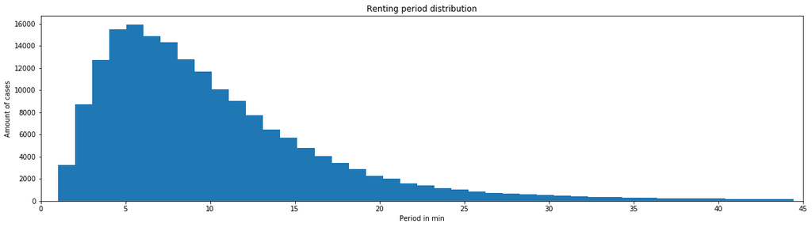

```python
# renting period statistics
# define delta step and limits
dlt = 1.01
x_lim1 = fgb_df.rent_period_min.min()-dlt
x_lim2 = 45
bins = np.arange(x_lim1, x_lim2, dlt)
# figure size
plt.figure(figsize = [20, 5])
plt.hist(data=fgb_df, x='rent_period_min', bins = bins);
# add x axis limits to remove outliers
plt.xlim((x_lim1,x_lim2));

add_info('Renting period distribution', 'Period in min', 'Amount of cases')
```

```python
#investigate long period cases
long_prd = fgb_df.query('rent_period_min > @x_lim2')
print('Percent of records with long period:', long_prd.shape[0]/fgb_df.shape[0]*100)
print('Maximum period:', long_prd.rent_period_min.max(), 'min')
long_prd.sample(5)
```

```
Percent of records with long period: 1.4966023524274759
Maximum period: 1424.06666667 min
```

|  | duration_sec | start_time | end_time | start_station_id | start_station_name | start_station_latitude | start_station_longitude | end_station_id | end_station_name | end_station_latitude | ... | member_birth_year | member_gender | bike_share_for_all_trip | start_day_of_week | end_day_of_week | start_hour | end_hour | rent_period_min | direct_distance_m | member_age |
| --- | --- | --- | --- | --- | --- | --- | --- | --- | --- | --- | --- | --- | --- | --- | --- | --- | --- | --- | --- | --- | --- |
| 139693 | 3182 | 2019-02-07 19:48:21.389 | 2019-02-07 20:41:24.316 | 3 | Powell St BART Station (Market St at 4th St) | 37.786375 | -122.404904 | 34 | Father Alfred E Boeddeker Park | 37.783988 | ... | 1976 | Male | True | Thursday | Thursday | 19-20 | 20-21 | 53.033333 | 711.855209 | 43 |
| 84848 | 4748 | 2019-02-17 15:23:57.243 | 2019-02-17 16:43:05.888 | 371 | Lombard St at Columbus Ave | 37.802746 | -122.413579 | 371 | Lombard St at Columbus Ave | 37.802746 | ... | 1994 | Female | True | Sunday | Sunday | 15-16 | 16-17 | 79.133333 | 0.000000 | 25 |
| 64746 | 3323 | 2019-02-20 10:19:48.737 | 2019-02-20 11:15:12.398 | 59 | S Van Ness Ave at Market St | 37.774814 | -122.418954 | 61 | Howard St at 8th St | 37.776513 | ... | 1968 | Male | True | Wednesday | Wednesday | 10-11 | 11-12 | 55.383333 | 699.397817 | 51 |
| 24718 | 7330 | 2019-02-25 15:57:49.166 | 2019-02-25 17:59:59.976 | 305 | Ryland Park | 37.342725 | -121.895617 | 303 | San Pedro St at Hedding St | 37.352601 | ... | 1995 | Male | True | Monday | Monday | 15-16 | 17-18 | 122.166667 | 1415.505289 | 24 |
| 204 | 3413 | 2019-02-28 21:38:01.453 | 2019-02-28 22:34:54.707 | 159 | 24th St at Market St | 37.816060 | -122.278244 | 159 | 24th St at Market St | 37.816060 | ... | 1993 | Female | True | Thursday | Thursday | 21-22 | 22-23 | 56.883333 | 0.000000 | 26 |

5 rows × 23 columns

#### Question:

How does distance distribution looks like? What is the main distance of movements? Some ouliers?

#### Visualization:

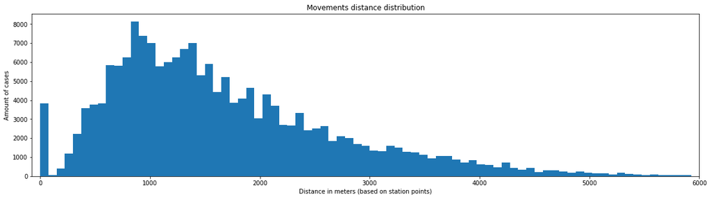

```python
# renting distance statistics
# define delta step and limits
dlt = 75.01
x_lim1 = fgb_df.direct_distance_m.min()-dlt
x_lim2 = 6000
bins = np.arange(x_lim1, x_lim2, dlt)
# figure size
plt.figure(figsize = [20, 5])
plt.hist(data=fgb_df, x='direct_distance_m', bins = bins);
# add x axis limits to remove outliers
plt.xlim((x_lim1,x_lim2));

add_info('Movements distance distribution', 'Distance in meters (based on station points)', 'Amount of cases')
```

```python
#investigate long distance cases
long_dist = fgb_df.query('direct_distance_m > @x_lim2')
print('Percent of records with long distance:', long_dist.shape[0]/fgb_df.shape[0]*100)
print('Maximum distance:', long_dist.direct_distance_m.max(), 'meters')
long_dist.sample(5)
```

```
Percent of records with long distance: 0.3886144693393008
Maximum distance: 69443.2551069 meters
```

|  | duration_sec | start_time | end_time | start_station_id | start_station_name | start_station_latitude | start_station_longitude | end_station_id | end_station_name | end_station_latitude | ... | member_birth_year | member_gender | bike_share_for_all_trip | start_day_of_week | end_day_of_week | start_hour | end_hour | rent_period_min | direct_distance_m | member_age |
| --- | --- | --- | --- | --- | --- | --- | --- | --- | --- | --- | --- | --- | --- | --- | --- | --- | --- | --- | --- | --- | --- |
| 156177 | 1277 | 2019-02-06 07:59:11.279 | 2019-02-06 08:20:28.379 | 245 | Downtown Berkeley BART | 37.870139 | -122.268422 | 181 | Grand Ave at Webster St | 37.811377 | ... | 1960 | Male | True | Wednesday | Wednesday | 07-08 | 08-09 | 21.283333 | 6526.135358 | 59 |
| 52946 | 2543 | 2019-02-21 16:04:21.859 | 2019-02-21 16:46:45.013 | 194 | Lakeshore Ave at Trestle Glen Rd | 37.811081 | -122.243268 | 245 | Downtown Berkeley BART | 37.870139 | ... | 0 | Other | True | Thursday | Thursday | 16-17 | 16-17 | 42.383333 | 6916.524417 | 2019 |
| 42561 | 1317 | 2019-02-22 17:13:19.900 | 2019-02-22 17:35:17.005 | 15 | San Francisco Ferry Building (Harry Bridges Pl... | 37.795392 | -122.394203 | 361 | Mendell St at Fairfax Ave | 37.739853 | ... | 1989 | Male | True | Friday | Friday | 17-18 | 17-18 | 21.950000 | 6207.958007 | 30 |
| 146966 | 1334 | 2019-02-07 08:05:11.557 | 2019-02-07 08:27:26.443 | 145 | 29th St at Church St | 37.743684 | -122.426806 | 24 | Spear St at Folsom St | 37.789677 | ... | 1981 | Female | True | Thursday | Thursday | 08-09 | 08-09 | 22.233333 | 6025.454825 | 38 |
| 172009 | 1468 | 2019-02-03 17:30:01.264 | 2019-02-03 17:54:29.372 | 6 | The Embarcadero at Sansome St | 37.804770 | -122.403234 | 147 | 29th St at Tiffany Ave | 37.744067 | ... | 1993 | Male | True | Sunday | Sunday | 17-18 | 17-18 | 24.466667 | 6923.999167 | 26 |

5 rows × 23 columns

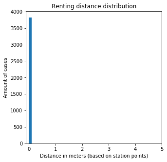

```python
# renting distance statistics (very small distnces)
# define delta step and limits
dlt = 0.11
x_lim1 = fgb_df.direct_distance_m.min()-dlt
x_lim2 = 5
bins = np.arange(x_lim1, x_lim2, dlt)
# figure size
plt.figure(figsize = [5, 5])
plt.hist(data=fgb_df, x='direct_distance_m', bins = bins);
# add x axis limits to remove outliers
plt.xlim((x_lim1,x_lim2));

add_info('Renting distance distribution', 'Distance in meters (based on station points)', 'Amount of cases')
```

```python
# investigate reasons for "zero-distance" records
zero_dist = fgb_df.query('direct_distance_m < 0.1')
print('Percent of records with returning to the same station:', zero_dist.shape[0]/fgb_df.shape[0]*100)
zero_dist.sample(5)
```

```
Percent of records with returning to the same station: 2.0860737385039436
```

|  | duration_sec | start_time | end_time | start_station_id | start_station_name | start_station_latitude | start_station_longitude | end_station_id | end_station_name | end_station_latitude | ... | member_birth_year | member_gender | bike_share_for_all_trip | start_day_of_week | end_day_of_week | start_hour | end_hour | rent_period_min | direct_distance_m | member_age |
| --- | --- | --- | --- | --- | --- | --- | --- | --- | --- | --- | --- | --- | --- | --- | --- | --- | --- | --- | --- | --- | --- |
| 169753 | 5335 | 2019-02-04 07:55:32.224 | 2019-02-04 09:24:27.728 | 125 | 20th St at Bryant St | 37.759200 | -122.409851 | 125 | 20th St at Bryant St | 37.759200 | ... | 1992 | Female | True | Monday | Monday | 07-08 | 09-10 | 88.916667 | 0.0 | 27 |
| 14223 | 130 | 2019-02-27 13:03:49.204 | 2019-02-27 13:06:00.142 | 16 | Steuart St at Market St | 37.794130 | -122.394430 | 16 | Steuart St at Market St | 37.794130 | ... | 1952 | Male | True | Wednesday | Wednesday | 13-14 | 13-14 | 2.166667 | 0.0 | 67 |
| 3930 | 2116 | 2019-02-28 16:17:02.073 | 2019-02-28 16:52:18.735 | 281 | 9th St at San Fernando St | 37.338395 | -121.880797 | 281 | 9th St at San Fernando St | 37.338395 | ... | 1991 | Female | True | Thursday | Thursday | 16-17 | 16-17 | 35.266667 | 0.0 | 28 |
| 159924 | 72 | 2019-02-05 17:39:08.346 | 2019-02-05 17:40:20.721 | 363 | Salesforce Transit Center (Natoma St at 2nd St) | 37.787492 | -122.398285 | 363 | Salesforce Transit Center (Natoma St at 2nd St) | 37.787492 | ... | 1988 | Male | True | Tuesday | Tuesday | 17-18 | 17-18 | 1.200000 | 0.0 | 31 |
| 84568 | 79 | 2019-02-17 17:23:45.870 | 2019-02-17 17:25:05.134 | 4 | Cyril Magnin St at Ellis St | 37.785881 | -122.408915 | 4 | Cyril Magnin St at Ellis St | 37.785881 | ... | 1991 | Female | True | Sunday | Sunday | 17-18 | 17-18 | 1.316667 | 0.0 | 28 |

5 rows × 23 columns

### 3.2. Renting statistics

#### Question:

How does distribution during week days looks like? What are the main days of renting? Some specifities?

#### Visualization:

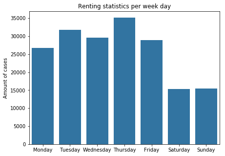

```python
# renting distribution per week day
# figure size
plt.figure(figsize = [7, 5])
# normal day order
day_order = ['Monday','Tuesday','Wednesday','Thursday','Friday','Saturday','Sunday']
# single color
base_color = sb.color_palette()[0]
sb.countplot(data=fgb_df, x='start_day_of_week', color=base_color, order=day_order);
add_info('Renting statistics per week day', '', 'Amount of cases');
```

#### Observation:

Amount of renting cases during working days are approximatelly 2 times more then during weekends.  
Bike are used mainly for work or transport to work and back.  
Some peacks are durint Tuesday and Thursday.

#### Question:

How does distribution during day hours looks like? What are the main hours of renting? Some specifities?

#### Visualization:

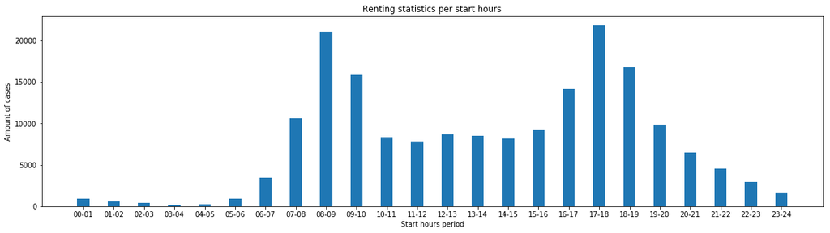

```python
# renting distribution per week day
# figure size
plt.figure(figsize = [20, 5])
# normal hour order
hour_order = fgb_df.start_hour.value_counts()
hour_order.sort_index(inplace=True)
# single color for start_hour
base_color = sb.color_palette()[0]
plt.bar(hour_order.index, hour_order.values, color=base_color, width = 0.4);

add_info('Renting statistics per start hours', 'Start hours period', 'Amount of cases');
```

#### Observation:

Peack hours of renting are 8-10AM and 16-19PM.  
Downtime period from 23PM til 06AM.  
During the day hours rent volume approximatelly half of the peacks.

#### Question:

How does distribution during user ages look like? What are the main ages of users? Some specifities?

#### Visualization:

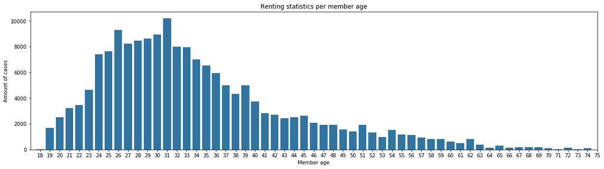

```python
# renting distribution per age
#define delta step and limits
x_lim1 = -1
x_lim2 = 57
#figure size
plt.figure(figsize = [20, 5])
# single color
base_color = sb.color_palette()[0]
sb.countplot(data=fgb_df, x='member_age', color=base_color)
#add x axis limits to remove outliers
plt.xlim((x_lim1,x_lim2));

add_info('Renting statistics per member age', 'Member age', 'Amount of cases');
```

#### Observation:

Main users for this service are young people in ages from 23 till 39.  
Some peacks in ages 26 and 31.

### 3.3. User statistics

#### Question:

How does gender split and split of user types looks like? Some specifities?

#### Visualization:

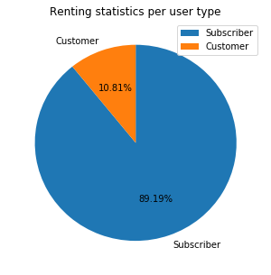

```python
# renting distribution per user_type
#figure size
plt.figure(figsize = [5, 5])
user_counts = fgb_df.user_type.value_counts()
plt.pie(user_counts, labels = user_counts.index, startangle = 90, counterclock = False, autopct=prcnt_value);
add_info('Renting statistics per user type', '','');
```

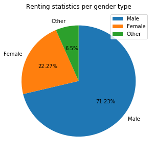

```python
# renting distribution per gender
#figure size
plt.figure(figsize = [5, 5])
user_counts = fgb_df.member_gender.value_counts()
plt.pie(user_counts, labels = user_counts.index, startangle = 90, counterclock = False, autopct=prcnt_value);
add_info('Renting statistics per gender type', '','');
```

### 3.4. Conclusions:

All these datas explain that bikes are used on regular bases by young people for short movements mainly on morning and evening hours (partially during the day) during working days as main trasport vehicle for movement (as an exaple to work and back). Downtime period (good for maintenance) is midnight till 6AM.

Back to table of content

## 4. Bivariate Exploration

```python
# load clean dataset (not to repeat cleaning process)
if 'fgb_df' not in globals():
    # if start without cleaning - load clean data set
    # import all packages and set plots to be embedded inline
    import numpy as np
    import pandas as pd
    import matplotlib.pyplot as plt
    import seaborn as sb
    %matplotlib inline

    fgb_df = pd.read_csv('fordgobike_clean.csv', parse_dates=['start_time','end_time'])
    fgb_df.info()
else:
    print('Data set "fgb_df" aready existed.')
```

```
Data set "fgb_df" aready existed.
```

### Define visualization support functions

```python
# define function to add visualization info
def add_info(ttl, x_lbl, y_lbl, lgnd=[], x_tck=[], x_tcklbl=[], y_tck=[], y_tcklbl=[]):
    plt.title(ttl)
    plt.xlabel(x_lbl)
    plt.ylabel(y_lbl)
    if lgnd:
        plt.legend(lgnd)
    else:
        plt.legend()

    if x_tck:
        plt.xticks(x_tck, x_tcklbl)

    if y_tck:
        plt.xticks(y_tck, y_tcklbl)
```

### 4.1. Scattering time and distance

#### Question:

Is any correlation between renting time and movement distance? Some specifities? Proposal to plot full scope and if needed some specific areas.

#### Visualization:

```
Correlation coef: 0.126922007136
```

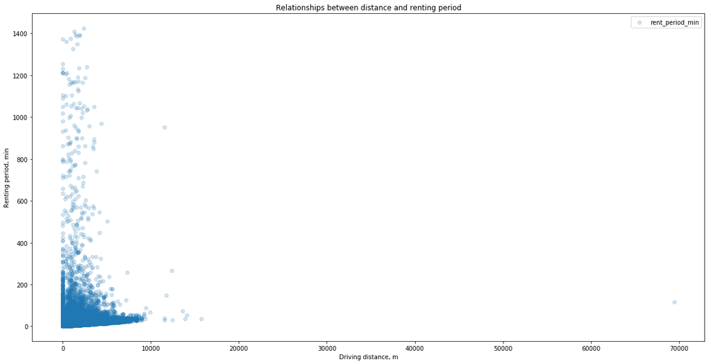

```python
# relationships between distance and renting period (full scope)
plt.figure(figsize = [20, 10])
plt.scatter(data = fgb_df, x = 'direct_distance_m', y = 'rent_period_min', alpha=0.2);

add_info('Relationships between distance and renting period', 'Driving distance, m', 'Renting period, min');

print('Correlation coef:', fgb_df.direct_distance_m.corr(fgb_df.rent_period_min))
```

#### Observation:

- outliers points both for distance and time make picture not clear
- idea: to limint distance till 5000 m and time till 30 min
- use sampling to reduse amount of points

#### Question:

How does shorter rent period and distance correlation look like?

#### Visualization:

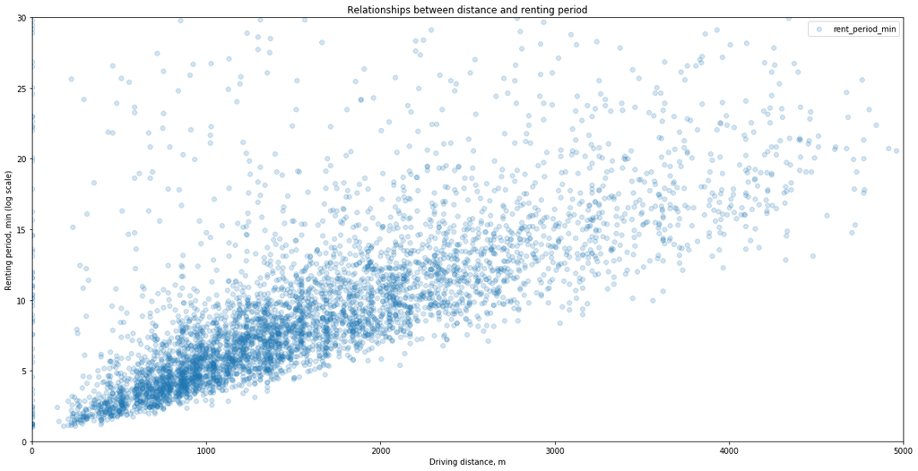

```python
# relationships between distance and renting period
#define delta step and limits
x_lim1 = 0
x_lim2 = 5000
y_lim1 = 0
y_lim2 = 30

#figure size
plt.figure(figsize = [20, 10])
plt.scatter(data = fgb_df.sample(5000), x = 'direct_distance_m', y = 'rent_period_min', alpha=0.2);

#add axis limits to remove outliers
plt.xlim((x_lim1, x_lim2));
plt.ylim((y_lim1, y_lim2));

add_info('Relationships between distance and renting period', 'Driving distance, m', 'Renting period, min (log scale)');
```

#### Observation:

- now relationship is more clear and looks linear
- to proof correlation: lets reduce dataset to proposed limits and check precision and correlation

```python
# select sub set of data bsed on selected above coordinate limits
sub_fgb_df = fgb_df.query('direct_distance_m < 4500 and rent_period_min < 25')
print('Ratio of selected subset records:', sub_fgb_df.shape[0]/fgb_df.shape[0]*100, "%")
```

```
Ratio of selected subset records: 93.3122288022269 %
```

```python
print('Correlation coef:', sub_fgb_df.direct_distance_m.corr(sub_fgb_df.rent_period_min))
```

```
Correlation coef: 0.758303609141
```

#### Observation:

- in main scope (93% of total) renting cases there is clear correlation beetwen renting time and distance.
- logically this is driving speed limits.

### 4.2. Time and distance during days and hours

#### Question:

Is average renting period different during week days?

#### Visualization:

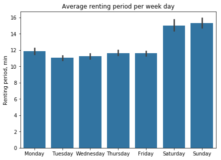

```python
# violin plot for renting period and day of week
# normal day order
day_order = ['Monday','Tuesday','Wednesday','Thursday','Friday','Saturday','Sunday']
#figure size
plt.figure(figsize = [7, 5])
# single color
base_color = sb.color_palette()[0]
sb.barplot(data=fgb_df, x='start_day_of_week', y='rent_period_min', color=base_color, order=day_order);

add_info('Average renting period per week day', '', 'Renting period, min');
```

#### Observation:

- an average during working days renting period is shorter for 3 min and also less variable from min to max.

#### Question:

Now check if is average movement distance different during week days?

#### Visualization:

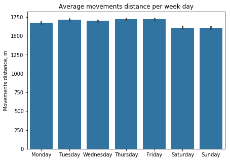

```python
# violin plot for distance and day of week
# normal day order
day_order = ['Monday','Tuesday','Wednesday','Thursday','Friday','Saturday','Sunday']
# figure size
plt.figure(figsize = [7, 5])
# single color
base_color = sb.color_palette()[0]
sb.barplot(data=fgb_df, x='start_day_of_week', y='direct_distance_m', color=base_color, order=day_order);

add_info('Average movements distance per week day', '', 'Movements distance, m');
```

#### Observation:

- an average during working days distance is longer for couple of handreds meters (looks people cycle to another directions)

#### Question:

Is average renting period different during days hours?

#### Visualization:

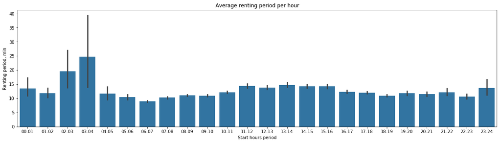

```python
# normal hour order
hour_order = fgb_df.start_hour.value_counts()
hour_order.sort_index(inplace=True)
# figure size
plt.figure(figsize = [20, 5])
# single color
base_color = sb.color_palette()[0]
sb.barplot(data=fgb_df, x='start_hour', y='rent_period_min', color=base_color, order=hour_order.index);

add_info('Average renting period per hour', 'Start hours period', 'Renting period, min');
```

#### Observation:

- during morning and evening peacks renting period is shorter (people are hurry to work)
- during nights and mids of the day renting period is longer (looks people cycle slowly)
- an average during nights periods are more variable (people more "discover" or "walk" during cycling)

#### Question:

Is average distnace different during days hours?

#### Visualization:

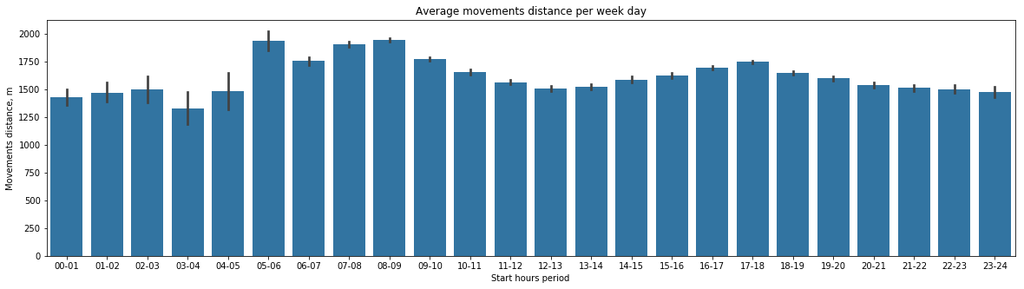

```python
# normal hour order
hour_order = fgb_df.start_hour.value_counts()
hour_order.sort_index(inplace=True)
# figure size
plt.figure(figsize = [20, 5])
# single colo
base_color = sb.color_palette()[0]
sb.barplot(data=fgb_df, x='start_hour', y='direct_distance_m', color=base_color, order=hour_order.index);

add_info('Average movements distance per week day', 'Start hours period', 'Movements distance, m');
```

#### Observation:

- during morning and evening peacks distnace is longer and less variable (specific destinations)
- during nights and mids of the day distnace is shorter
- an average during nights distance are more variable (similat to periods of renting)

### 4.3. Conclusions:

- based on avearge distance and period during working days it's possible to make following supposition:  
  at weekends people are cycling bikes more slowly and to another directions (for examples to shops, not to work)
- distribution of period and distance during days and hours also support supposition above.  
  during working days mornings and evenings people use bikes to go to work (specific distance and time to cycle)

Back to table of content

## 5. Multivariate Exploration

```python
# load clean dataset (not to repeat cleaning process)
if 'fgb_df' not in globals():
    # if start without cleaning - load clean data set
    # import all packages and set plots to be embedded inline
    import numpy as np
    import pandas as pd
    import matplotlib.pyplot as plt
    import seaborn as sb
    %matplotlib inline

    fgb_df = pd.read_csv('fordgobike_clean.csv', parse_dates=['start_time','end_time'])
    fgb_df.info()
else:
    print('Data set "fgb_df" aready existed.')
```

```
Data set "fgb_df" aready existed.
```

### Define visualization support functions

```python
# define function to add visualization info
def add_info(ttl, x_lbl, y_lbl, lgnd=[], x_tck=[], x_tcklbl=[], y_tck=[], y_tcklbl=[]):
    plt.title(ttl)
    plt.xlabel(x_lbl)
    plt.ylabel(y_lbl)
    if lgnd:
        plt.legend(lgnd)
    else:
        plt.legend()

    if x_tck:
        plt.xticks(x_tck, x_tcklbl)

    if y_tck:
        plt.xticks(y_tck, y_tcklbl)
```

### 5.1. Contracts and gender correlation with days and hours

#### Question:

Is any difference between contract types during week days?

#### Visualization:

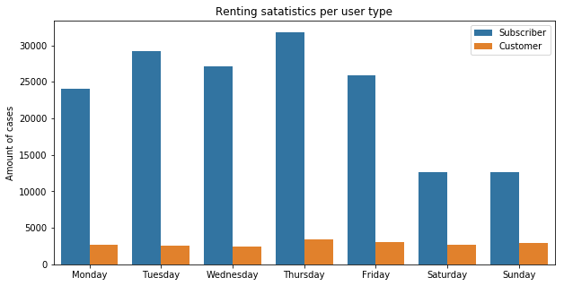

```python
# plot correlation beetwen days and contracts
# figure size
plt.figure(figsize = [10, 5])
# normal day order
day_order = ['Monday','Tuesday','Wednesday','Thursday','Friday','Saturday','Sunday']
# prefered hue order
user_hue_order=['Subscriber', 'Customer']
sb.countplot(data=fgb_df, x='start_day_of_week', hue='user_type', hue_order=user_hue_order, order=day_order);

add_info('Renting satatistics per user type', '', 'Amount of cases');
```

#### Observation:

- total customer orders numbers during week are the same but during weekends ratio of customer orders higher

#### Question:

Is any difference between contract types during hours?

#### Visualization:

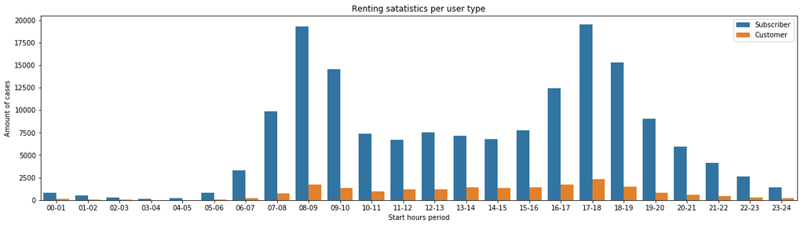

```python
# plot correlation beetwen hours and contracts
# figure size
plt.figure(figsize = [20, 5])
# normal hour order
hour_order = fgb_df.start_hour.value_counts()
hour_order.sort_index(inplace=True)
# prefered hue order
user_hue_order=['Subscriber', 'Customer']
sb.countplot(data=fgb_df, x='start_hour', hue='user_type', hue_order=user_hue_order, order=hour_order.index);

add_info('Renting satatistics per user type', 'Start hours period', 'Amount of cases');
```

#### Observation:

- in general customer orders ratio similar to subscriber orders

#### Question:

Is any difference between gender split during days?

#### Visualization:

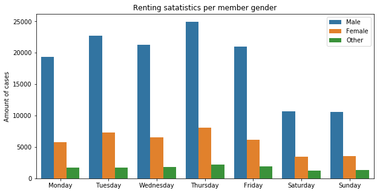

```python
# plot correlation beetwen days and genders
# normal day order
day_order = ['Monday','Tuesday','Wednesday','Thursday','Friday','Saturday','Sunday']
# figure size
plt.figure(figsize = [10, 5])
# prefered gender order
memb_hue_order=['Male','Female','Other']
sb.countplot(data=fgb_df, x='start_day_of_week', hue='member_gender', hue_order=memb_hue_order, order=day_order);

add_info('Renting satatistics per member gender', '', 'Amount of cases');
```

#### Observation:

- in general genders ratio similar during all days of week

#### Question:

Is any difference between gender split during hours?

#### Visualization:

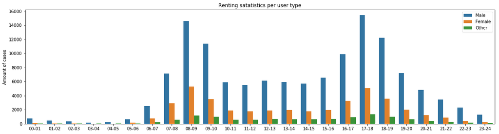

```python
# plot correlation beetwen hours and genders
# figure size
plt.figure(figsize = [20, 5])
# normal hour order
hour_order = fgb_df.start_hour.value_counts()
hour_order.sort_index(inplace=True)
# prefered gender order
memb_hue_order=['Male','Female','Other']
sb.countplot(data=fgb_df, x='start_hour', hue='member_gender', hue_order=memb_hue_order, order=hour_order.index);

add_info('Renting satatistics per user type', '', 'Amount of cases');
```

#### Observation:

- in general genders ratio similar during all hours of the day

### 5.2. Rent and return distribution

#### Question:

How does distribution between rent and return bike look like? Is any shortage of bikes during day? Some specifities?

#### Visualization:

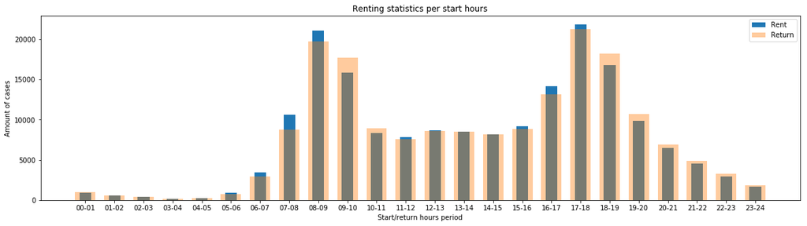

```python
# renting distribution per week day
# figure size
plt.figure(figsize = [20, 5])
# normal hour order
hour_order = fgb_df.start_hour.value_counts()
hour_order.sort_index(inplace=True)
# single color for start_hour
base_color = sb.color_palette()[0]
plt.bar(hour_order.index, hour_order.values, color=base_color, width = 0.4);

hour_order = fgb_df.end_hour.value_counts()
hour_order.sort_index(inplace=True)
# single color for end_hour
base_color = sb.color_palette()[1]
plt.bar(hour_order.index, hour_order.values, color=base_color, width = 0.7, alpha = 0.4);

add_info('Renting statistics per start hours', 'Start/return hours period', 'Amount of cases', ['Rent', 'Return']);
```

#### Observation:

Peack hours of renting are 8-10AM and 16-19PM.  
In general return time distribution is equal renting time except small delays during picks hours.  
It's expected result because renting period approximatelly 15 min, bikes are returned quite quickly.

#### Question:

How does distribution between rent and return bike on station level look like? Is any shortage of bikes at specific station? Some specifities?

#### Visualization:

```python
# lets select additional station statistics for rent
rent_stations = fgb_df.start_station_id.value_counts()
rent_stations = pd.DataFrame(rent_stations)
# lets select additional station statistics for return
return_stations = fgb_df.end_station_id.value_counts()
return_stations = pd.DataFrame(return_stations)

# lets select stations names
station_names = fgb_df[['start_station_id','start_station_name']]
idx = station_names[station_names.duplicated()].index
station_names = station_names.drop(labels=idx, axis=0)
#rename columns
station_names.columns = ['station_id_', 'station_name']
```

```python
# lets create additional dataset for station rent and return and names
rent_return_df = rent_stations.copy()
rent_return_df = rent_stations.merge(return_stations, how='left',
                                     left_on=rent_stations.index, right_on=return_stations.index)
# change columns names
rent_return_df.columns = ['station_id', 'rented', 'returned']

# add stations names
rent_return_df = rent_return_df.merge(station_names, how='left',
                                     left_on=rent_return_df.station_id, right_on=station_names.station_id_)
# drop index column from second table
rent_return_df.drop(labels=['key_0','station_id_'], axis=1, inplace=True)

#change type to category
rent_return_df.station_name = rent_return_df.station_name.astype('category')

# table overview
rent_return_df.head(5)
```

|  | station_id | rented | returned | station_name |
| --- | --- | --- | --- | --- |
| 0 | 58 | 3904 | 3973 | Market St at 10th St |
| 1 | 67 | 3544 | 4857 | San Francisco Caltrain Station 2 (Townsend St... |
| 2 | 81 | 3052 | 2872 | Berry St at 4th St |
| 3 | 21 | 2895 | 3647 | Montgomery St BART Station (Market St at 2nd St) |
| 4 | 3 | 2760 | 2997 | Powell St BART Station (Market St at 4th St) |

```python
# save cleaned dataset
rent_return_df.to_csv("rnt_rtrn_fordgobike_clean.csv", index=False)
```

```python
# melt dataset to create 3-rd categorical variavle
id_vars = ['station_id', 'station_name']
value_vars = ['rented', 'returned']
rent_return_df_plt = rent_return_df.melt(id_vars=id_vars, value_vars=value_vars, var_name='action', value_name='case_qnty')

# change type to category
rent_return_df.station_name = rent_return_df.station_name.astype('category')
```

[figure not shown]

```python
# renting/return distribution per stations
# figure size
plt.figure(figsize = [10, 100])
sb.barplot(data = rent_return_df_plt, x = 'case_qnty', y = 'station_name', hue = 'action')

add_info('Rent/return statistics per stations', 'Amount of cases','Stations');
```

#### Observation:

At most of the stations amount of rentings and returns close to each other.  
However at some station there is disbalance, therefore redistribution is needed.  
List of stations shown below. Detailed reasons and frequency to be investigated separatelly.

```python
# add parameter with difference
rent_return_df['difference'] = rent_return_df.rented - rent_return_df.returned

# select stations with difference more than 50
dif_max = 100
redistr_stations = rent_return_df.query('difference < -@dif_max or difference > @dif_max')

print("Amount of staions for bike distribution (over ", dif_max, "bikes/month) is:", redistr_stations.shape[0] )
```

```
Amount of staions for bike distribution (over  100 bikes/month) is: 37
```

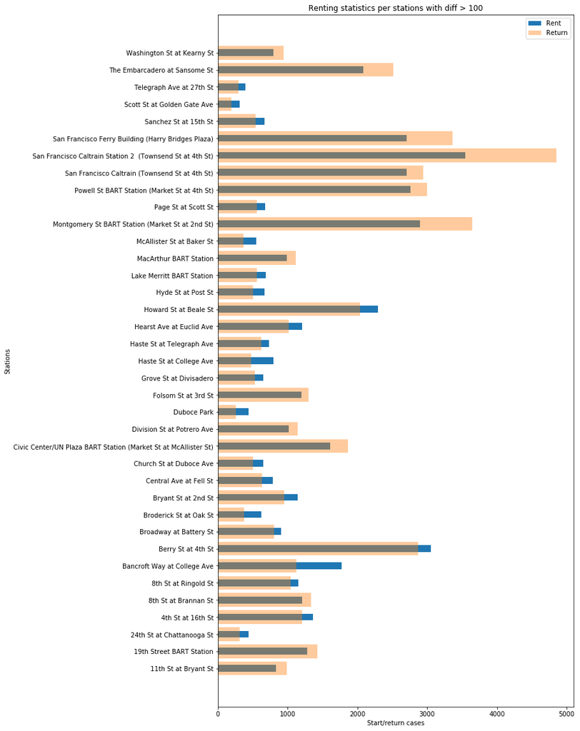

```python
# renting distribution per week day
# figure size
plt.figure(figsize = [10, 20])
# single color for stations
base_color = sb.color_palette()[0]
plt.barh(redistr_stations.station_name, redistr_stations.rented, color=base_color, height=0.4)
#plt.xticks(rotation=45);

# single color for stations
base_color = sb.color_palette()[1]
plt.barh(redistr_stations.station_name, redistr_stations.returned, color=base_color, height=0.8, alpha=0.4)

add_info('Renting statistics per stations with diff > 100', 'Start/return cases', 'Stations', ['Rent', 'Return']);
```

### 5.3. Period and distance for contract and gender types

#### Question:

Is any difference in correlation due to contract type?

#### Visualization:

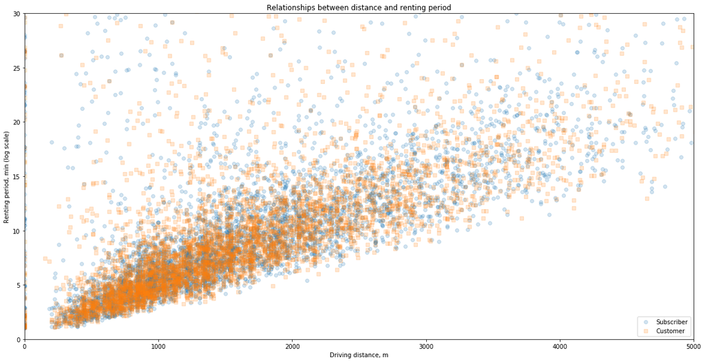

```python
# relationships between distance and renting period on contract level
# define markers
cat_markers = [['Subscriber', 'o'],
               ['Customer', 's']]

#define delta step and limits
x_lim1 = 0
x_lim2 = 5000
y_lim1 = 0
y_lim2 = 30

#figure size
plt.figure(figsize = [20, 10])

for cat, plt_marker in cat_markers:
    df_cat = fgb_df[fgb_df.user_type == cat]
    plt.scatter(data = fgb_df.sample(5000), x = 'direct_distance_m', y = 'rent_period_min', alpha=0.2, marker = plt_marker);

#add axis limits to remove outliers
plt.xlim((x_lim1, x_lim2));
plt.ylim((y_lim1, y_lim2));
add_info('Relationships between distance and renting period', 'Driving distance, m', 'Renting period, min (log scale)',
         ['Subscriber', 'Customer'] );
```

```python
# select sub set of data based on selected above coordinate limits
sub_fgb_df = fgb_df.query('direct_distance_m < 4500 and rent_period_min < 25')
print('Ratio of selected subset records:', sub_fgb_df.shape[0]/fgb_df.shape[0]*100, "%")
```

```
Ratio of selected subset records: 93.3122288022269 %
```

```python
# select sub set of data for customer contract
sub_fgb_df_cus = sub_fgb_df.query('user_type == "Customer"')
print('Ratio of selected subset records:', sub_fgb_df_cus.shape[0]/fgb_df.shape[0]*100, "%")
print('Correlation coef:', sub_fgb_df_cus.direct_distance_m.corr(sub_fgb_df_cus.rent_period_min))
```

```
Ratio of selected subset records: 8.68869906939934 %
Correlation coef: 0.595776030848
```

```python
# select sub set of data for customer contract
sub_fgb_df_sub = sub_fgb_df.query('user_type == "Subscriber"')
print('Ratio of selected subset records:', sub_fgb_df_sub.shape[0]/fgb_df.shape[0]*100, "%")
print('Correlation coef:', sub_fgb_df_sub.direct_distance_m.corr(sub_fgb_df_sub.rent_period_min))
```

```
Ratio of selected subset records: 84.62352973282755 %
Correlation coef: 0.780515015621
```

#### Observation:

In general no big difference from results in 4.1 block.  
In details, customer oreders correlation is less than for subscribers (thats also looks logical based on conclusions above)

#### Question:

Is any difference in correlation due to gender type?

#### Visualization:

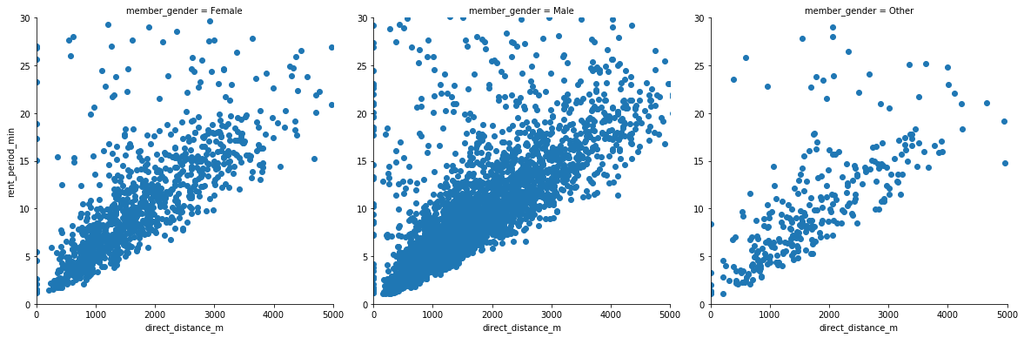

```python
# relationships between distance and renting period on gender level
# define delta step and limits
x_lim1 = 0
x_lim2 = 5000
y_lim1 = 0
y_lim2 = 30


g = sb.FacetGrid(data = fgb_df.sample(5000), col = 'member_gender', size = 5.5,
                margin_titles = True)
g.map(plt.scatter, 'direct_distance_m', 'rent_period_min')

#add axis limits to remove outliers
plt.xlim((x_lim1, x_lim2));
plt.ylim((y_lim1, y_lim2));
```

#### Observation:

In general no big difference from results in 4.1 block.

### 5.4 Conclusions:

- during weekends customer orders ratio is higher but not significntly changed during the day hours.  
  gender ratio is nearly the same during day hours and week of the days.

  > Idea 1: as soom total level of orders lower and ratio of customer orders higher during weekends to introduse discounts for customer orders during weekends to compensate renting level drop during weekends.  
  > Idea 2: as soon as level of Female orders many less than Male to investigate reasons (may be byke types) to improve further total Female ratio.
- due to short period of renting in general there is no bike lacking issue (difference between rented and returned bikes).  
  however such problem available for specific stations (37 with more then 100 bikes per month).

  > Solution: to organize periodical redistribution or set some discounts for returning bikes to problematic stations.
- expectadly, for correlation of distnace and renting period there is no big impact from contracts or gender types.  
  block added to practice in different types of plotting.

Back to table of content

Back to table of content

```python
from subprocess import call
call(['python', '-m', 'nbconvert', 'Part_I_exploration_fordbike_renting.ipynb'])
```

```
0
```